# Exploring data_Hw2

Natalia Bonilla V

2025-03-11

## Tarea 2

- Una vez descargados, el primer paso será importar correctamente los datos a R, asegurándose de que el archivo se lea sin errores y se almacene en un objeto adecuado para su análisis.
- Deberá:
  - Calcular al menos cinco métricas estadísticas básicas para el análisis exploratorio del conjunto de datos(la media, la mediana, la desviación estándar, los valores máximos y mínimos).
  - Deberá realizar dos gráficos utilizando la librería ggplot2
  - El trabajo debe presentarse en un script o archivo RMarkdown
  - Código claramente comentado
  - Los resultados interpretados de forma clara y concisa
- Fuente de los datos, proveído por el profesor. Se cree que está en Kaggle.

```r
df <- read.csv("cars.csv")
head(df, 3)
```

```
##   manufacturer_name model_name transmission  color odometer_value year_produced
## 1            Subaru    Outback    automatic silver         190000          2010
## 2            Subaru    Outback    automatic   blue         290000          2002
## 3            Subaru   Forester    automatic    red         402000          2001
##   engine_fuel engine_has_gas engine_type engine_capacity body_type has_warranty
## 1    gasoline          False    gasoline             2.5 universal        False
## 2    gasoline          False    gasoline             3.0 universal        False
## 3    gasoline          False    gasoline             2.5       suv        False
##   state drivetrain price_usd is_exchangeable location_region number_of_photos
## 1 owned        all     10900           False    Минская обл.                9
## 2 owned        all      5000            True    Минская обл.               12
## 3 owned        all      2800            True    Минская обл.                4
##   up_counter feature_0 feature_1 feature_2 feature_3 feature_4 feature_5
## 1         13     False      True      True      True     False      True
## 2         54     False      True     False     False      True      True
## 3         72     False      True     False     False     False     False
##   feature_6 feature_7 feature_8 feature_9 duration_listed
## 1     False      True      True      True              16
## 2     False     False     False      True              83
## 3     False     False      True      True             151
```

```r
tail(df, 3)
```

```
##       manufacturer_name model_name transmission  color odometer_value
## 38529          Chrysler        300    automatic   blue         777957
## 38530          Chrysler PT Cruiser   mechanical  black          20000
## 38531          Chrysler    Voyager    automatic silver         297729
##       year_produced engine_fuel engine_has_gas engine_type engine_capacity
## 38529          2000    gasoline          False    gasoline             3.5
## 38530          2001    gasoline          False    gasoline             2.0
## 38531          2000    gasoline          False    gasoline             2.4
##       body_type has_warranty state drivetrain price_usd is_exchangeable
## 38529     sedan        False owned      front      4300           False
## 38530   minivan        False owned      front      4000            True
## 38531   minivan        False owned      front      3200            True
##       location_region number_of_photos up_counter feature_0 feature_1 feature_2
## 38529    Минская обл.                3         63     False      True     False
## 38530  Брестская обл.                7        156     False      True     False
## 38531    Минская обл.                4         73     False     False     False
##       feature_3 feature_4 feature_5 feature_6 feature_7 feature_8 feature_9
## 38529     False      True      True     False     False      True      True
## 38530     False     False     False     False     False     False      True
## 38531     False     False     False     False     False     False      True
##       duration_listed
## 38529             369
## 38530             490
## 38531             632
```

## Estructura de los Datos

Vamos a echar un vistazo a nuestros datos para conocerlos mejor.

- Con el **summary** vemos un resumen de nuestros datos y algunas características según el tipo de dato.

```r
summary(df)
```

```
##  manufacturer_name   model_name        transmission          color
##  Length:38531       Length:38531       Length:38531       Length:38531
##  Class :character   Class :character   Class :character   Class :character
##  Mode  :character   Mode  :character   Mode  :character   Mode  :character
##
##
##
##
##  odometer_value    year_produced  engine_fuel        engine_has_gas
##  Min.   :      0   Min.   :1942   Length:38531       Length:38531
##  1st Qu.: 158000   1st Qu.:1998   Class :character   Class :character
##  Median : 250000   Median :2003   Mode  :character   Mode  :character
##  Mean   : 248865   Mean   :2003
##  3rd Qu.: 325000   3rd Qu.:2009
##  Max.   :1000000   Max.   :2019
##
##  engine_type        engine_capacity  body_type         has_warranty
##  Length:38531       Min.   :0.200   Length:38531       Length:38531
##  Class :character   1st Qu.:1.600   Class :character   Class :character
##  Mode  :character   Median :2.000   Mode  :character   Mode  :character
##                     Mean   :2.055
##                     3rd Qu.:2.300
##                     Max.   :8.000
##                     NA's   :10
##     state            drivetrain          price_usd     is_exchangeable
##  Length:38531       Length:38531       Min.   :    1   Length:38531
##  Class :character   Class :character   1st Qu.: 2100   Class :character
##  Mode  :character   Mode  :character   Median : 4800   Mode  :character
##                                        Mean   : 6640
##                                        3rd Qu.: 8990
##                                        Max.   :50000
##
##  location_region    number_of_photos   up_counter       feature_0
##  Length:38531       Min.   : 1.000   Min.   :   1.00   Length:38531
##  Class :character   1st Qu.: 5.000   1st Qu.:   2.00   Class :character
##  Mode  :character   Median : 8.000   Median :   5.00   Mode  :character
##                     Mean   : 9.649   Mean   :  16.31
##                     3rd Qu.:12.000   3rd Qu.:  16.00
##                     Max.   :86.000   Max.   :1861.00
##
```

[output cut: 9 more lines]

```
##  Length:38531       Length:38531       Length:38531       Length:38531
##  Class :character   Class :character   Class :character   Class :character
##  Mode  :character   Mode  :character   Mode  :character   Mode  :character
##
##
##
##
##   feature_9         duration_listed
##  Length:38531       Min.   :   0.00
##  Class :character   1st Qu.:  23.00
##  Mode  :character   Median :  59.00
##                     Mean   :  80.58
##                     3rd Qu.:  91.00
##                     Max.   :2232.00
##
```

- Con el **str** podemos ver una lista de las variablesy su tipo de dato.

```r
str(df)
```

```
## 'data.frame':    38531 obs. of  30 variables:
##  $ manufacturer_name: chr  "Subaru" "Subaru" "Subaru" "Subaru" ...
##  $ model_name       : chr  "Outback" "Outback" "Forester" "Impreza" ...
##  $ transmission     : chr  "automatic" "automatic" "automatic" "mechanical" ...
##  $ color            : chr  "silver" "blue" "red" "blue" ...
##  $ odometer_value   : int  190000 290000 402000 10000 280000 132449 318280 350000 179000 571317 ...
##  $ year_produced    : int  2010 2002 2001 1999 2001 2011 1998 2004 2010 1999 ...
##  $ engine_fuel      : chr  "gasoline" "gasoline" "gasoline" "gasoline" ...
##  $ engine_has_gas   : chr  "False" "False" "False" "False" ...
##  $ engine_type      : chr  "gasoline" "gasoline" "gasoline" "gasoline" ...
##  $ engine_capacity  : num  2.5 3 2.5 3 2.5 2.5 2.5 2.5 2.5 2.5 ...
##  $ body_type        : chr  "universal" "universal" "suv" "sedan" ...
##  $ has_warranty     : chr  "False" "False" "False" "False" ...
##  $ state            : chr  "owned" "owned" "owned" "owned" ...
##  $ drivetrain       : chr  "all" "all" "all" "all" ...
```

[output cut: 16 more lines]

- Y finalmente **colnames** para tener más claro el nombre de las columnas del dataset.

```r
colnames(df)
```

```
##  [1] "manufacturer_name" "model_name"        "transmission"
##  [4] "color"             "odometer_value"    "year_produced"
##  [7] "engine_fuel"       "engine_has_gas"    "engine_type"
## [10] "engine_capacity"   "body_type"         "has_warranty"
## [13] "state"             "drivetrain"        "price_usd"
## [16] "is_exchangeable"   "location_region"   "number_of_photos"
## [19] "up_counter"        "feature_0"         "feature_1"
## [22] "feature_2"         "feature_3"         "feature_4"
## [25] "feature_5"         "feature_6"         "feature_7"
## [28] "feature_8"         "feature_9"         "duration_listed"
```

## Statistical metrics

### Max:

- Acá estamos usando **num_columns** para almacenar todos los rows de las columnas que solo son numéricas con *sapply.*
- En el *apply* se usa el 2 para que se aplique a cada columna, el *na.rm = TRUE* con el MARGIN = max para que devuelva el máximo de cada columna.

```r
num_columns <- df[, sapply(df, is.numeric)]

max_values <- apply(num_columns, 2, max, na.rm = TRUE)
max_values
```

```
##   odometer_value    year_produced  engine_capacity        price_usd
##          1000000             2019                8            50000
## number_of_photos       up_counter  duration_listed
##               86             1861             2232
```

### Min:

- Por acá usamos la misma estructura del MAX pero esta vez con el mínimo

```r
min_values <- apply(num_columns, 2, min, na.rm = TRUE)
min_values
```

```
##   odometer_value    year_produced  engine_capacity        price_usd
##              0.0           1942.0              0.2              1.0
## number_of_photos       up_counter  duration_listed
##              1.0              1.0              0.0
```

### Average:

- Seguidamente guardamos en **cols_avg** los *promedios* de las columnas numéricas que pudimos ver en la función anterior* str(df)* e imprimirlas.
- Importante mencionar que cuando *na.rm es TRUE* ignora los datos NA para hacer los cálculos.

```r
#average = colMeans(df[,5:6])
col_avg <- sapply(num_columns, mean, na.rm = TRUE)
col_avg
```

```
##   odometer_value    year_produced  engine_capacity        price_usd
##     2.488646e+05     2.002944e+03     2.055161e+00     6.639971e+03
## number_of_photos       up_counter  duration_listed
##     9.649062e+00     1.630609e+01     8.057725e+01
```

### Median

Esta se utiliza para representar el valor central de un conjunto de datos y es menos sensible a valores atípicos que el promedio.

- Estamos aplicando a **num_colums** que usamos anteriormente, para obtener la mediana de las columnas numéricas.
- Acá usamos *apply*, pero se puede hacer la operación con *sapply* también, los 2 general el mismo resultado. La estructura para el *sapply* seria col_median <- sapply(num_columns, median, na.rm = TRUE).
  - **Apply**: Se usa en matrices o data frame, cuando se quiere especificar si uasr rows o columns. apply(X, MARGIN, FUN, …): X = df | MARGIN = 1 rows o 2 columns | FUN = mean, median, sum, sd | … = argumentos para FUN
  - **Sapply**: Se aplica una funcion a cada elemento de la lista o vector. sapply(X, FUN): X = df | FUN = mean, median, sum | … = argumentos para FUN

```r
col_median <- apply(num_columns, 2, median, na.rm = TRUE)
col_median
```

```
##   odometer_value    year_produced  engine_capacity        price_usd
##           250000             2003                2             4800
## number_of_photos       up_counter  duration_listed
##                8                5               59
```

### Stantard Derivation

Esta sirve para medir la dispersión o variabilidad de los datos alrededor de la media/promedio.

Una **SD alta** significa que los datos están más dispersos, mientras que una **SD baja** indica que los datos están más agrupados alrededor de la media o promedio.

- La usaremos para:
  - **Entender la dispersión:** Permite evaluar la homogeneidad o heterogeneidad de los datos.
  - **Identificar outliers:** Valores extremos que se desvían significativamente de la media pueden ser detectados con la desviación estándar.
  - **Comparar conjuntos** de datos: Permite comparar la dispersión de diferentes variables o grupos de datos.
  - **Tomar decisiones:** Ayuda a tomar decisiones informadas sobre la calidad y la representatividad de los datos.

Acá usamos *apply*, con la misma estructura que usamos para la mediana. solo cambiando la función en FUN a sd

```r
column_sd <- apply(num_columns, 2, sd, na.rm = TRUE)
column_sd
```

```
##   odometer_value    year_produced  engine_capacity        price_usd
##     1.360724e+05     8.065731e+00     6.711777e-01     6.428152e+03
## number_of_photos       up_counter  duration_listed
##     6.093217e+00     4.328693e+01     1.128266e+02
```

### Mean, Meadian & Standard Derivation conclusions:

Como ejemplo vamos a analizar 2 de las variables a las que les aplicamos el promedio, la median y la desviación estándar.

1. Odometer Value
- Mean: 2.488646e+05 ~ 248,864.6
- Median: 250000 = 250,000
- SD: 1.360724e+05 ~ 136,072.4

El promedio y la mediana están bastante cerca (248,864.6 vs 250,000) lo que sugiere que la distribución es casi simétrica o aproximada.

La DE está relativamente alta (136,072.4) indicando una amplia dispersión en los valores. Quiere decir que hay una variabilidad significativa en el recorrido de los carros.

2. Price (USD)
- Mean: 6.639971e+03 ~ 6,639.97
- Median: 4800 ~ 4,800
- SD: 6.428152e+03 ~ 6,428.15

El promedio es significativamente más alto que la mediana (6,639.97 vs. 4,800), esto puede sugerir que hay valores atípicos de precios altos que impulsan el promedio al alza.

La DE es grande (6428.15) lo que puede confirmar una amplia dispersión de los precios. Existe una variabilidad significativa en el costo de los carros.

## Visualizations

```r
library(ggplot2)
library(ggthemes)
library(tidyr)
```

### Histogram

Vemos que se acerca a ser simétrico porque la media y la mediana estaban cerca (248,864.6 vs 250,000), pero con algunos valores fuera de rango que nos indicó la DE.

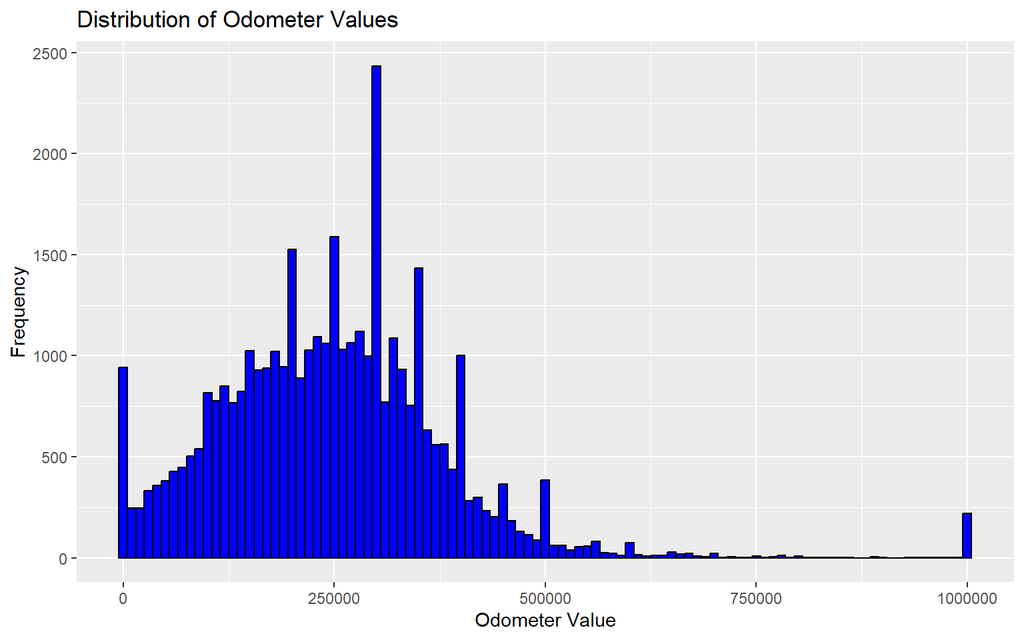

```r
ggplot(df, aes(x = odometer_value)) +
  geom_histogram(binwidth = 10000, fill = "blue", color = "black") +
  labs(title = "Distribution of Odometer Values",
       x = "Odometer Value",
       y = "Frequency")
```

### Boxplots

Para Visualizar los Outliers de odometer_value que pudimos deducir en la DE.

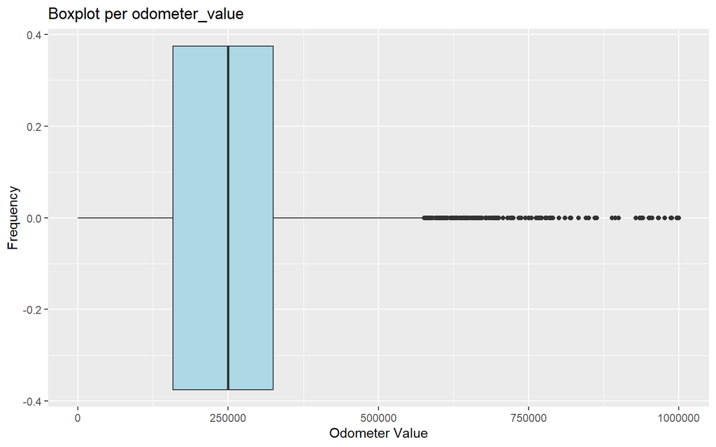

```r
ggplot(df, aes(x = odometer_value)) +
  geom_boxplot(fill="lightblue") +
  labs(title = "Boxplot per odometer_value",
       x = "Odometer Value",
       y = "Frequency")
```

### Price_usd

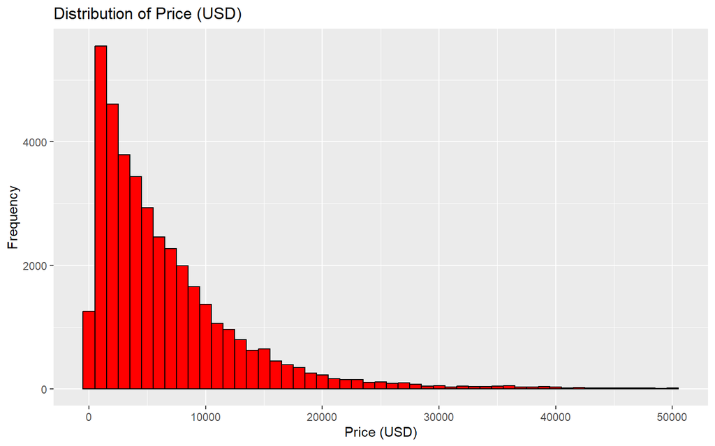

```r
ggplot(df, aes(x = price_usd)) +
  geom_histogram(binwidth = 1000, fill = "red", color = "black") +
  labs(title = "Distribution of Price (USD)",
       x = "Price (USD)",
       y = "Frequency")
```

Para Visualizar los Outliers de **price_usd** que pudimos deducir en el SD

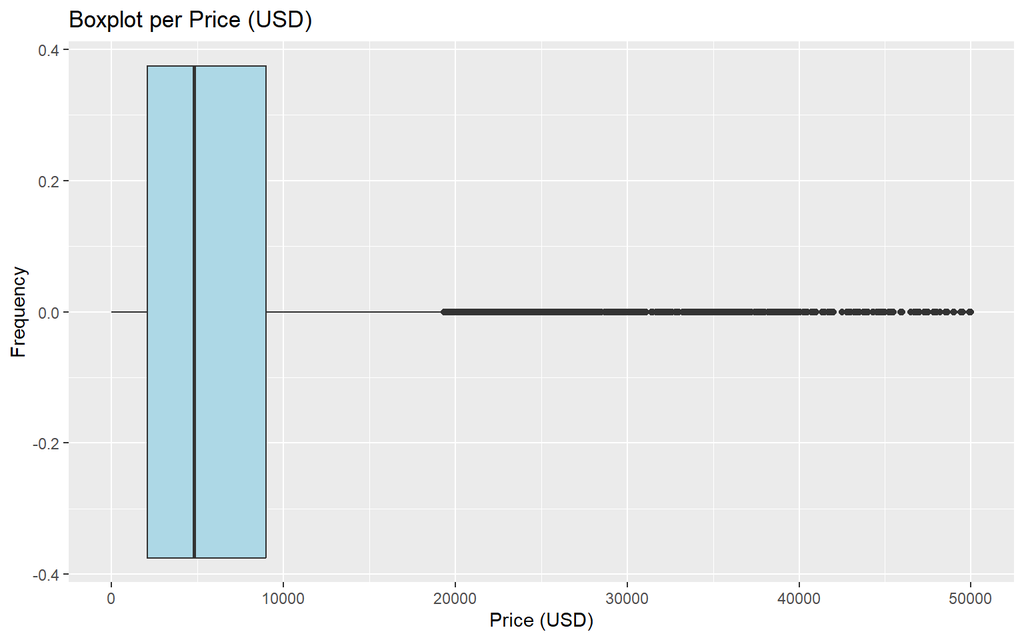

```r
ggplot(df, aes(x = price_usd)) +
  geom_boxplot(fill="lightblue") +
  labs(title = "Boxplot per Price (USD)",
       x = "Price (USD)",
       y = "Frequency")
```

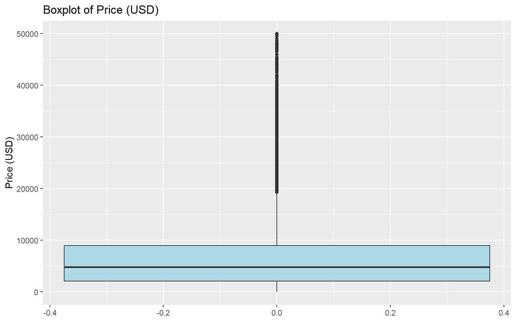

```r
ggplot(df, aes(y = price_usd)) +
  geom_boxplot(fill = "lightblue") +
  labs(title = "Boxplot of Price (USD)",
       y = "Price (USD)")
```